# Programando IA com R

### Conceitos de variáveis

**Vetor**

Toda variável no R é um vetor, um vetor pode visto como um conjunto de valores linear e homogêneo.

Para atribuir um valor à uma variável, utilizamos a seta <- indicando para onde estamos direcionando o valor.

É importante saber também, que para criar um vetor com valores, podemos utilizar a função c() que combina os valores em um vetor

Sendo assim, abaixo estamos criando a variável vetor e atribuindo o valor 1 5 4

```r
vetor <- c(1, 5, 4)

vetor
```

### Tipos de valores

**Numéricos e Caracteres**

No R tempos o conceito de tipos, onde cada valor tem um tipo específico, lembra das aulas de matemática sobre inteiros, decimais, etc?

Para verificar o tipo interpretado pelo R de um valor, podemos utilizar a função class(valor), onde valor é igual ao valor que você quer verificar.

```r
class(5)
class("Olá mundo")
```

**Reconhecendo tipos de variáveis**

Isto também se aplica a variáveis, veja só:

```r
variavel_numerica <- c(1,5,4,7)
variavel_caracteres <- c("Olá mundo")

class(variavel_numerica)
class(variavel_caracteres)
```

Também podemos usar as funções disponíveis em “is” para verificar os tipos, essa verificação retorna um tipo lógico para nós

```r
variavel <- "5"
is.numeric(variavel)
is.character(variavel)
```

**Lógicos**

No R, também é possível criar tipos lógicos (verdadeiro ou falso)

```r
logicos <- c(TRUE, FALSE, TRUE)
logicos2 <- c(T, F, T)

logicos
logicos2

class(logicos)
```

Veja que é possível abreviar as declarações.

**Inteiros Explicitos**

Você deve ter percebido que no caso do tipo numérico, o tipo não foi declarado explicitamente como inteiro, para fazer isso veja o próximo trecho:

```r
inteiros <- c(1L, 2L, 3L)

inteiros
class(inteiros)
```

### Gerando sequências

Gerar sequências no R é uma coisa muito fácil e divertida! Temos algumas formas para fazer isso:

```r
#Gerando números de 1 a 10
1:10

#Gerando números de 10 a 1
10:1

#Gerando números de 100 a 120

seq(100, 120)

#Gerando 10 números a partir de 100

seq(100, length.out = 10)

#Gerando números de 10 a 20 de 2 em 2

seq.int(from = 10, to = 20, by = 2)

#Gerando 20 números

seq_len(20)

#Gerando um vetor do mesmo tamanho que o vetor passado

seq_along(c(70, 2))

#Repetindo o número 4 5 vezes

rep(4, times = 5)
```

**NA, NaN, Inf, -Inf e NULL**

Os tipos especiais são valores que possuem uma característica bem específica.

NA = Não disponível (Not Available) NaN = Não númerico (Not A Number) Inf = Infinito -Inf = -Infinito NULL = Vazio

Perceba que NA possui um tipo, mas NULL não, NULL representa o nada no caso do R e de diversas linguagens de programação.

Um detalhe é que não é possível colocar NULL em um vetor, ou seja, caso criemos um vetor com NULL, o R remove ele automáticamente

```r
valor.na <- NA
valor.null <- NULL
valor.infinito <- Inf;
valor.menos.infinito <- -Inf
valor.nan <- NaN
vetor.com.null <- c(10,10,10,NULL)
vetor.com.null
```

```
[1] 10 10 10
```

### Operações aritméticas

No R é possível fazer operações aritméticas entre os valores disponíveis, abaixo teremos exemplos para algumas operações aritméticas simples:

```r
# Adição
adicao <- 5+5
adicao

# Subtração
subtracao <- 5-5
subtracao

# Multiplicação
multiplicao <- 5*5
multiplicao

# Divisão
divisao <- 5/5
divisao

#Raiz Quadrada

raiz <- sqrt(10)
raiz

#Numero imaginário
numero <- 1i
numero
```

**Operações com vetores**

As operações aritméticas se estendem a vetores também, veja abaixo um exemplo:

```r
# Vetor de dez posições
vetor <- c(1:10)

vetor * 2

# Veja que obtemos o dobro de cada valor do vetor, isso se aplica para todas as operações.
```

[output not shown]

### Tipos avançados

**Fatores**

Através de fatores, é possível classificar dados para que as máquinas consigam processar com mais facilidade. Veja que no output, o R escreve “Levels: Feminino Masculino” para identificar as classes encontradas.

```r
sexo <- c("Feminino", "Masculino","Feminino", "Masculino","Feminino", "Masculino","Feminino", "Masculino","Feminino", "Masculino")
fatorado <- as.factor(sexo);
fatorado
```

```
 [1] Feminino  Masculino Feminino  Masculino Feminino  Masculino Feminino  Masculino
 [9] Feminino  Masculino
Levels: Feminino Masculino
```

**Listas**

No R, temos o tipo de lista onde é possível armazenar vetores com tipos diferentes:

```r
v1 <- c(1, 2, 3);
v2 <- c(T, F, T);
v3 <- c("a", "b", "c");
lista <- list(v1, v2, v3)

class(lista)

lista
```

**Matrizes**

```r
matriz <- matrix(ncol = 5, nrow = 5, data = 1:5)

matriz
```

Você deve ter percebido que também é possível atribuir uma matriz para uma variável com esse exemplo.

Vamos a um exemplo de operação com matrizes

```r
matrizA <- matrix(ncol = 5, nrow = 5, data = 1:5)
matrizB <- matrix(ncol = 5, nrow = 5, data = 1:5)
# Esta operação abaixo não é uma multiplicação de matrizes, é apenas uma multiplicação de valores.
matriz <- matrizA * matrizB
matriz
```

```
     [,1] [,2] [,3] [,4] [,5]
[1,]    1    1    1    1    1
[2,]    4    4    4    4    4
[3,]    9    9    9    9    9
[4,]   16   16   16   16   16
[5,]   25   25   25   25   25
```

Para fazermos uma multiplicaçáo de matrizes, precisamos seguir uma regra: a quantidade de colunas da matriz A deve ser equivalente a quantidade de linhas da matriz B.

Abaixo um exemplo de multiplicação de matrizes:

```r
linhas <- 5
colunas <- 10
matrizA <- matrix(ncol = linhas, nrow = colunas, data = 1:2)
matrizB <- matrix(ncol = colunas, nrow = linhas, data = 1:2)
matrizA %*% matrizB
```

```
      [,1] [,2] [,3] [,4] [,5] [,6] [,7] [,8] [,9] [,10]
 [1,]    7    8    7    8    7    8    7    8    7     8
 [2,]   14   16   14   16   14   16   14   16   14    16
 [3,]    7    8    7    8    7    8    7    8    7     8
 [4,]   14   16   14   16   14   16   14   16   14    16
 [5,]    7    8    7    8    7    8    7    8    7     8
 [6,]   14   16   14   16   14   16   14   16   14    16
 [7,]    7    8    7    8    7    8    7    8    7     8
 [8,]   14   16   14   16   14   16   14   16   14    16
 [9,]    7    8    7    8    7    8    7    8    7     8
[10,]   14   16   14   16   14   16   14   16   14    16
```

**Funções úteis para matrizes**

```r
matrizA <- matrix(ncol = 2, nrow = 2, data = 1:4)
print("Dimensões da matriz - Linhas x Colunas")
```

```
[1] "Dimensões da matriz - Linhas x Colunas"
```

```r
dim(matrizA)  #inversa, esta deve ser quadrada
```

```
[1] 2 2
```

```r
print("Transposta")
```

```
[1] "Transposta"
```

```r
t(matrizA) #transposta
```

```
     [,1] [,2]
[1,]    1    2
[2,]    3    4
```

```r
print("Identidade")
```

```
[1] "Identidade"
```

```r
diag(matrizA) #identidade
```

```
[1] 1 4
```

```r
print("Inversa")
```

```
[1] "Inversa"
```

```r
solve(matrizA)  #inversa, esta deve ser quadrada
```

```
     [,1] [,2]
[1,]   -2  1.5
[2,]    1 -0.5
```

```r
matrizA <- cbind(matrizA, c(5,2)) #Adiciona colunas no fim da matriz
#Colunas adicionadas
print("Colunas adicionadas")
```

```
[1] "Colunas adicionadas"
```

```r
matrizA
```

```
     [,1] [,2] [,3]
[1,]    1    3    5
[2,]    2    4    2
```

```r
print("Linhas adicionadas")
```

```
[1] "Linhas adicionadas"
```

```r
matrizA <- rbind(matrizA, c(5,2, 3))
matrizA
```

```
     [,1] [,2] [,3]
[1,]    1    3    5
[2,]    2    4    2
[3,]    5    2    3
```

**Data Frame**

Criar um dataframe é bem simples, veja:

```r
vetorA <- c(1,5,4,7)
vetorB <- c("Olá mundo")
dataframe <- data.frame(vetorA, vetorB)
# Colocando nomes nas colunas
colnames(dataframe) <- c("Numérico", "Texto")
dataframe
```

| Numérico | Texto |
| --- | --- |
| 1 | Olá mundo |
| 5 | Olá mundo |
| 4 | Olá mundo |
| 7 | Olá mundo |

O mais legal do dataframe, é que conseguimos colocar dados heterogêneos, ao contrário dos vetores e matrizes.

Também é possível criar um dataframe a partir de uma lista:

```r
lista <- list(c(1,2), c(T,F), c("teste", "teste2"))
dataframe <- data.frame(lista)
dataframe
```

| c.1..2. | c.TRUE..FALSE. | c..teste....teste2.. |
| --- | --- | --- |
| 1 | TRUE | teste |
| 2 | FALSE | teste2 |

**Datas**

Geralmente o trabalho com datas é uma das coisas mais complexas em programação. Vamos ver aqui algumas funções que o R disponibiliza para nós:

```r
data.texto = "13/11/2018 T 19:10:00"
data.date = as.Date(data.texto,format="%d/%m/%Y T %H:%M:%S",tz="America/Sao_Paulo")
data.time1 = as.POSIXct(data.texto,format="%d/%m/%Y T %H:%M:%S",tz="America/Sao_Paulo")
data.time2 = as.POSIXlt(data.texto,format="%d/%m/%Y T %H:%M:%S",tz="America/Sao_Paulo")
data.time1
```

```
[1] "2018-11-13 19:10:00 -02"
```

```r
data.time2
```

```
[1] "2018-11-13 19:10:00 -02"
```

```r
data.date
```

```
[1] "2018-11-13"
```

Através do método unclass, podemos ver o conteúdo real de uma variável, suas propriedades e etc. Quando passamos data.date para a função unclass, obtemos a quantidade de dias desde 01/01/1970 até a data da variável.

```r
unclass(data.date)
```

```
[1] 17848
```

No caso de time1 e time2 veja que não temos diferenças no texto, entretanto veja quando fazemos o unclass.

```r
print("Time1")
```

```
[1] "Time1"
```

```r
unclass(data.time1)
```

```
[1] 1542143400
attr(,"tzone")
[1] "America/Sao_Paulo"
```

```r
print("Time2")
```

```
[1] "Time2"
```

```r
unclass(data.time2)
```

```
$`sec`
[1] 0

$min
[1] 10

$hour
[1] 19

$mday
[1] 13

$mon
[1] 10

$year
[1] 118

$wday
[1] 2

$yday
[1] 316

$isdst
[1] 1

$zone
[1] "-02"

$gmtoff
[1] NA

attr(,"tzone")
[1] "America/Sao_Paulo"
```

O unclass no time1 retorna a contagem em segundos desde 01/01/1970 até a data da variável!!

Para obter a data atual

```r
Sys.Date()
```

```
[1] "2018-12-01"
```

**Lubridate**

Lubridate é um pacote disponibilizado para manipular datas no R. Para instalar e carregar:

```r
install.packages("lubridate")
library(lubridate)
```

O lubridate fornece funções que retornarão a data no formato solicitado e além disso ele trabalha com o conceito de duração.

```r
segundos  = dseconds(260)
minutos  = dminutes(260)
anos  = dyears(260)
duration(10, units = "seconds")
```

```
[1] "10s"
```

```r
segundos
```

```
[1] "260s (~4.33 minutes)"
```

```r
minutos
```

```
[1] "15600s (~4.33 hours)"
```

```r
anos
```

```
[1] "8199360000s (~259.82 years)"
```

```r
#abaixo as funções de data
#Ano mes dia
data <- ymd("20190101")
# Dia mes ano hora
dmy_h("1110201810")
```

```
[1] "2018-10-11 10:00:00 UTC"
```

```r
# Retorna o dia da semana
wday(data, label = T)
```

```
[1] Tue
Levels: Sun < Mon < Tue < Wed < Thu < Fri < Sat
```

### Estruturas de controle

Para tomar algumas decisões durante a execução de código, o R fornece algumas estruturas de controle.

```r
souBonito <- TRUE
if (souBonito) {
  print("Eu Sei")
} else {
  print("Vish")
}
```

```
[1] "Eu Sei"
```

```r
souBonito <- F
ifelse(souBonito, "verdade", "falso")
```

```
[1] "falso"
```

Estruturas de controle são muito úteis quando você precisa testar algum tipo de condição, se alguma compra foi realizada por exemplo, ou se algo ocorreu.

### Estruturas de repetição = loops

Loops são utilizados quando precisamos por exemplo repetir um conjunto de instruções para determinados itens.

```r
itens <- c(10,20,30)
for (variable in itens) {
  print(variable)
}
```

```
[1] 10
[1] 20
[1] 30
```

Veja que escrevemos todos os itens do vetor na tela, podemos utilizar para consolidar informações e enfim, para qualquer conjunto de instruções que precise se repetir.

Vamos montar um dataframe com um loop

```r
vetor <- 1:10
acumulado <- 0
tabela <- data.frame();
for (variable in vetor) {
  acumulado <- variable + acumulado
   tabela <- rbind(tabela, c(variable, acumulado))
}
colnames(tabela) <- c("Valor1", "Acumulado")
tabela
```

| Valor1 | Acumulado |
| --- | --- |
| 1 | 1 |
| 2 | 3 |
| 3 | 6 |
| 4 | 10 |
| 5 | 15 |
| 6 | 21 |
| 7 | 28 |
| 8 | 36 |
| 9 | 45 |
| 10 | 55 |

### Funções

Funções são utilizadas quando queremos reaproveitar algum trecho de código específico. por exemplo, digamos que precisamos calcular o enesimo termo de uma Progressão Aritmética

```r
primeiro.termo <- 1
razao<- 2
obter.termo.pa <- function(primeiro.termo, numero.termo, razao) {
  return(primeiro.termo + (numero.termo - 1) * razao)
}
obter.termo.pa(primeiro.termo, 50, razao)
```

```
[1] 99
```

Em funções, podemos receber reticências como parametro, que significa que podemos receber N parametros na função. Um exemplo de função assim é a função paste.

```r
concatena <- function(...) {
  c <- paste(...)
  c
}
concatena("Sergio", "Prates")
```

```
[1] "Sergio Prates"
```

### Amostras

No R possuimos a função sample para randomizar a ocorrência de determinados valores

```r
# Letras de a até g
amostra1 <- letters[1:7]
# Letras de A até D
amostra2 <- LETTERS[1:4]
# Pode repetir as ocorrências
sample(x = amostra1, size = 20, replace = T)
```

```
 [1] "a" "d" "f" "a" "e" "a" "g" "d" "d" "e" "e" "b" "d" "g" "a" "a" "d" "e" "c" "c"
```

```r
# Não pode repetir as ocorrências
sample(x = amostra2, size = 3,  replace = F)
```

```
[1] "C" "D" "A"
```

Para garantir que sempre o mesmo resultado aconteça, podemos utilizar a função set.seed com um valor fixo

```r
set.seed(1)
sample(x = amostra1, size = 20, replace = T)
```

```
 [1] "b" "c" "e" "g" "b" "g" "g" "e" "e" "a" "b" "b" "e" "c" "f" "d" "f" "g" "c" "f"
```

### Simulações

O R nos fornecea alguns comandos para gerar dados aleatórios, sendo eles da família normal, binomial e uniforme.

Os comandos da familia normal possuem norm no final, os binomiais possuem binom e assim por diante… Veja abaixo exemplos:

```r
set.seed(18) #garantindo que sempre sairá o mesmo resultado
# sd representa o desvio padrão dos dados
print("rnorm")
```

```
[1] "rnorm"
```

```r
rnorm(n=10, mean=0, sd=1)
```

```
 [1]  0.92645924  1.82282117 -1.61056690 -0.28510975 -0.34207303  0.36617615
 [7] -1.32704085  2.41259221  0.06381535  1.54551478
```

```r
print("dnorm")
```

```
[1] "dnorm"
```

```r
dnorm(x = 1:10, mean = 0, sd = 1)
```

```
 [1] 2.419707e-01 5.399097e-02 4.431848e-03 1.338302e-04 1.486720e-06 6.075883e-09
 [7] 9.134720e-12 5.052271e-15 1.027977e-18 7.694599e-23
```

```r
print("pnorm")
```

```
[1] "pnorm"
```

```r
pnorm( q = 1:10, mean = 0, sd = 1)
```

```
 [1] 0.8413447 0.9772499 0.9986501 0.9999683 0.9999997 1.0000000 1.0000000 1.0000000
 [9] 1.0000000 1.0000000
```

```r
print("rbinom")
```

```
[1] "rbinom"
```

```r
rbinom(size = 1:10, prob = c(0.1,0.1,0.1,0.1,0.1,0.1,1,1,1,1), n = 10)
```

```
 [1]  0  0  1  1  0  1  7  8  9 10
```

```r
print("dbinom")
```

```
[1] "dbinom"
```

```r
dbinom(size = 1:10, prob = c(0.1,0.1,0.1,0.1,0.1,0.1,1,1,1,1), x = 1:10)
```

```
 [1] 1e-01 1e-02 1e-03 1e-04 1e-05 1e-06 1e+00 1e+00 1e+00 1e+00
```

```r
print("pbinom")
```

```
[1] "pbinom"
```

```r
pbinom(q = 1:10, size = 1:10, prob = c(0.1,0.1,0.1,0.1,0.1,0.1,1,1,1,1))
```

```
 [1] 1 1 1 1 1 1 1 1 1 1
```

```r
print("Distribuição de poison")
```

```
[1] "Distribuição de poison"
```

```r
rpois(100, 5)
```

```
  [1]  5  5  3  4  8  5  3  3  3  6  8  5  6  5  2  2  7  1  3  5  3  3  6  6  1  4  3
 [28]  7  5  5  4  2  1  3  3  6  5 12  6  7  8  4  2 10  7  4  6  5  2  3  6  5  7  5
 [55]  6  6 11  5  6  7  7  4  5  3  6  6  7  4  2  6  4  6  4  6  3  4  3  7  6 13  4
 [82]  3  5  3  1  4  3  5  8  8  5  6  6  6  3  6  5  3  2  1
```

### Plots básico

Para fazer plots, ou gráficos em R podemos utilizar a função plot()

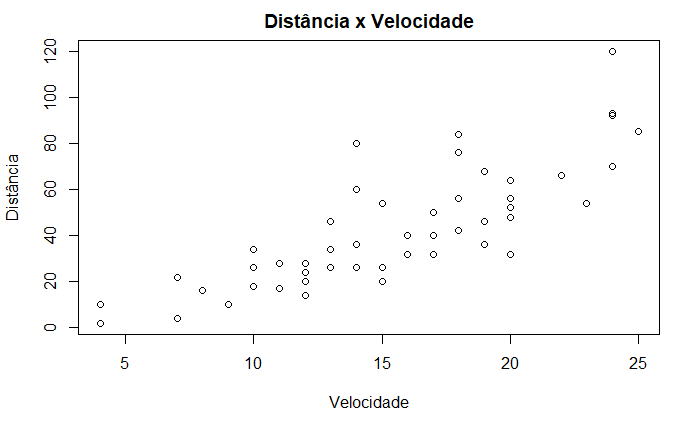

```r
plot(x = cars$speed, y = cars$dist, type = "p", xlab = "Velocidade", ylab = "Distância", main = "Distância x Velocidade")
```

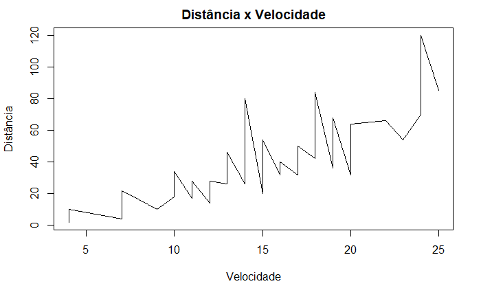

```r
plot(x = cars$speed, y = cars$dist, type = "l", xlab = "Velocidade", ylab = "Distância", main = "Distância x Velocidade")
```

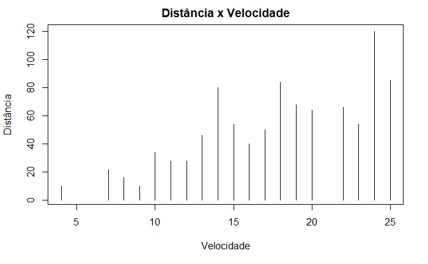

```r
plot(x = cars$speed, y = cars$dist, type = "h", xlab = "Velocidade", ylab = "Distância", main = "Distância x Velocidade")
```

$\beta_0 = 0,5$

$\beta_1 = 2,0$

$x\sim N(0;1²)$

$\epsilon\sim N(0;2²)$

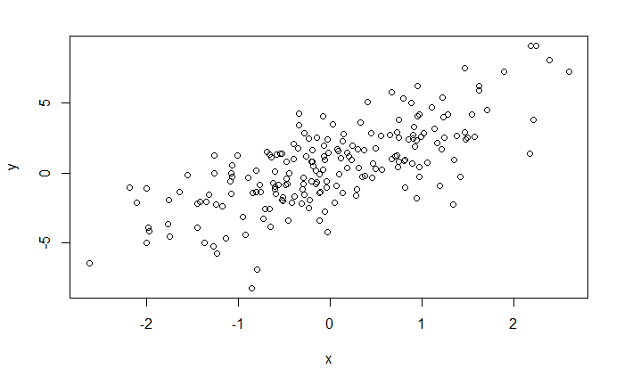

```r
set.seed(5)
x = rnorm(n=200, mean=0, sd=1)
e = rnorm(n=200, mean=0, sd=2)
y=0.5 + 2*x + e
plot(x=x, y=y,)
```